# Getting Started with ReSpectR

## Overview

**ReSpectR** extracts continuous and discrete relaxation spectra from rheological data in either the time domain $G(t)$ or the frequency domain $G^*(\omega)$.

The workflow has three stages:

1. Build a parameter list with `setParams()`
2. Compute the continuous spectrum $H(\tau)$ with `getContinuousSpectrum()`
3. Fit discrete Maxwell modes with `getDiscreteSpectrum()`

Results can be written to disk at any stage with `writeSpectrumResults()`.

## Input data format

### Time domain `domain = "time"`

A plain-text file with two or three white-space-separated columns:

```
#  t       G(t)      [optional weight]
0.001    1.2e5
0.01     8.4e4
...
```

If only two columns are provided the data are interpolated onto 100 log-equi-spaced points internally.

### Frequency domain `domain = "frequency"`

Three or five columns:

```
#  omega   G'(omega)  G''(omega)  [wt_Gp  wt_Gpp]
0.1       120.0      45.0
1.0       480.0     310.0
...
```

## Time-domain workflow

```r
# 1.  Build parameters
par <- setParams(
  domain   = "time",
  dataFile = time_file,
  ns       = 100L,       # spectral grid points
  lamC     = 0,          # 0 = automatic (Bayesian L-curve)
  verbose  = FALSE
)

# 2.  Continuous spectrum
crs <- getContinuousSpectrum(par)

class(crs)
```

```
#> [1] "respect_continuous_spectrum" "respect_spectrum_result"
#> [3] "list"
```

```r
# crs$s      — relaxation-time grid  (length ns)
# crs$H      — log-spectrum H(tau)   (length ns)
# crs$lamC   — optimal regularisation lambda

# 3.  Discrete Maxwell modes
drs <- getDiscreteSpectrum(par, crs = crs)

class(drs)
```

```
#> [1] "respect_discrete_spectrum" "respect_spectrum_result"
#> [3] "list"
```

```r
# drs$g      — mode weights
# drs$tau    — relaxation times
# drs$Nopt   — number of modes selected by AIC

# 4.  Save to disk
paths <- writeSpectrumResults(drs, outputDir = file.path(tempdir(), "respect_output_time"))
```

## Frequency-domain workflow

```r
par <- setParams(
  domain   = "frequency",
  dataFile = freq_file,
  ns       = 100L,
  plateau  = FALSE       # set TRUE to fit a plateau modulus G0
)

crs <- getContinuousSpectrum(par)
```

```
#>
#> (*) Start
#> (*) Loading Data File: /Users/kristian/Documents/GitHub/RRespect/inst/extdata/freq_tests/test1.dat...
#> (*) Initial Set up...
#> (*) Building the L-curve ...
#> L-curve: lamM = 4.2838e+00
#> (*) Extracting CRS ... lamM = 4.284e+00
#> (*) Done
```

```r
drs <- getDiscreteSpectrum(par, crs = crs)
```

[output not shown]

```r
writeSpectrumResults(drs, outputDir = file.path(tempdir(), "respect_output_freq"))
```

## Native plotting

ReSpectR result objects now carry stable classes and can be plotted directly with `plot()`.

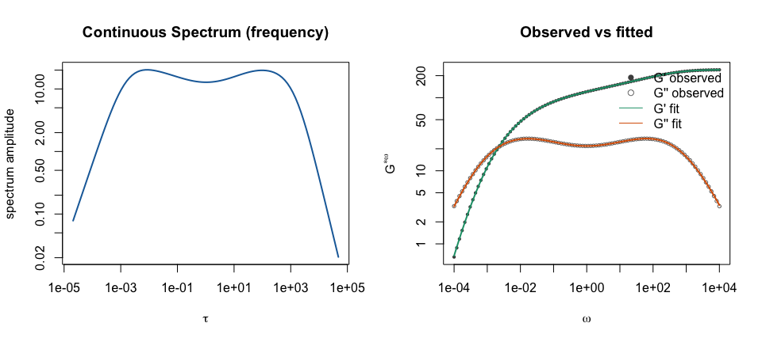

```r
plot(crs)
```

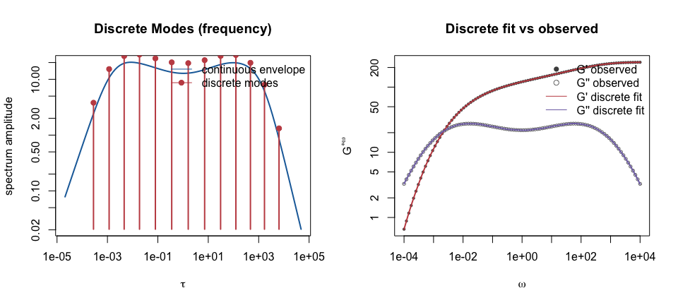

```r
plot(drs)
```

For continuous spectra, the native plot shows:

1. The recovered continuous spectrum amplitude across relaxation times.
2. The fitted response against the observed data.

For discrete spectra, the native plot shows:

1. Discrete Maxwell modes overlaid on the continuous envelope.
2. The discrete-mode reconstruction against the observed data.

## Batch processing

`runBatch()` processes a list of files and returns a data frame with one row per file.

```r
batch_dir <- file.path(tempdir(), "respect_batch_time")
dir.create(batch_dir, recursive = TRUE, showWarnings = FALSE)
file.copy(time_file, file.path(batch_dir, "test1.dat"), overwrite = TRUE)
```

```
#> [1] TRUE
```

```r
results <- runBatch(
  domain     = "time",
  dataDir    = batch_dir,
  outputRoot = file.path(tempdir(), "respect_batch_output")
)
```

```
#> [runBatch] ==================================================== 100% 1/1 test1
```

```r
# Inspect failures
results[results$status == "error", c("file", "message")]
```

```
#> [1] file    message
#> <0 rows> (or 0-length row.names)
```

Short-form aliases are available for scripting:

```r
par <- setParams(domain = "time", dataFile = time_file, verbose = FALSE)
crs <- contSpectrum(par)
drs <- discSpectrum(par, crs = crs)
writeResults(drs, outputDir = file.path(tempdir(), "respect_alias_output"))

# Batch aliases
runTimeBatch(dataDir = batch_dir, outputRoot = file.path(tempdir(), "respect_run_time_batch"))
```

```
#> [runBatch] ==================================================== 100% 1/1 test1
#>                                                                                               file
#> 1 /private/var/folders/r7/g6tyzlqs0wb233qkn4bhdvf40000gn/T/Rtmp5hCItf/respect_batch_time/test1.dat
#>   status      lamC Nopt     error message
#> 1     ok 0.4989116    5 0.1367336
```

```r
batch_dir_freq <- file.path(tempdir(), "respect_batch_freq")
dir.create(batch_dir_freq, recursive = TRUE, showWarnings = FALSE)
file.copy(freq_file, file.path(batch_dir_freq, "test1.dat"), overwrite = TRUE)
```

```
#> [1] TRUE
```

```r
runFrequencyBatch(dataDir = batch_dir_freq, outputRoot = file.path(tempdir(), "respect_run_freq_batch"))
```

[output not shown]

## Controlling output

All compute functions default to `writeOutput = FALSE` so they remain side-effect free. Use `writeSpectrumResults()` as the single explicit output path:

```r
# No files written during computation
crs <- getContinuousSpectrum(par, writeOutput = FALSE)
drs <- getDiscreteSpectrum(par, crs = crs, writeOutput = FALSE)

# Write everything at once
writeSpectrumResults(c(crs, drs), outputDir = file.path(tempdir(), "respect_output_control"))
```

## Parameter reference

| Parameter | Default | Description |
| --- | --- | --- |
| `domain` | `"time"` | `"time"` or `"frequency"` |
| `dataFile` | `"Gt.dat"` / `"Gst.dat"` | Input file path |
| `ns` | `100` | Spectral grid points |
| `lamC` | `0` | Regularisation lambda (0 = auto) |
| `smFacLam` | `0` | Lambda smoothing shift ∈ [−1, 1] |
| `freqEnd` | `1` | Spectrum end-condition: 1, 2, or 3 |
| `plateau` | `FALSE` | Fit plateau modulus G₀ (frequency domain) |
| `maxNumModes` | `0` | Cap on discrete modes (0 = uncapped) |
| `deltaBaseWeightDist` | `0.2` | AIC base-weight grid spacing |
| `minTauSpacing` | `1.25` | Minimum τ ratio between adjacent modes |
| `lamMin` / `lamMax` | `1e-10` / `1e3` | Lambda scan range |
| `lamDensity` | `3` | Lambda scan points per decade |

See `?setParams` for full documentation.